# JHU_PML Project

Michael Hunt

August 19, 2015

## Clean the workspace

rm(list=ls())

## Download the data and read into R

```r
# download training data if not yet already done so
if(!file.exists("./data/training.csv")){
        fileURL<-"https://d396qusza40orc.cloudfront.net/predmachlearn/pml-training.csv"
        download.file(fileURL,destfile="./data/training.csv")
        #include date of download
        datedownloadedtraining<-date()
        datedownloadedtraining

}

# download testing data if not yet already done so
if(!file.exists("./data/testing.csv")){
        fileURL<-"https://d396qusza40orc.cloudfront.net/predmachlearn/pml-testing.csv"
        download.file(fileURL,destfile="./data/testing.csv")
        #include date of download
        datedownloadedtesting<-date()
        datedownloadedtesting

}

# read csv file into dataframe
training<-read.csv("./data/training.csv")
testing<-read.csv("./data/testing.csv")
```

## Inspection of the data

```r
str(training)
str(testing)
summary(training)
summary(testing)
```

## Fist clean-up of the data

We remove all the logical variables from both training and testing sets, since they all have value NA for all 20 observations in the test set.

```r
library(dplyr)
testdf<-testing[,sapply(testing,is.factor)|sapply(testing,is.integer)
                |sapply(testing,is.numeric)]
traindf<-select(training,which(colnames(training) %in% names(testdf)))
traindf$classe<-training$classe
```

## Search for zero covariates

```r
library(caret)
nsv <- nearZeroVar(traindf,saveMetrics=TRUE)
nsv
```

```
##                      freqRatio percentUnique zeroVar   nzv
## X                     1.000000  100.00000000   FALSE FALSE
## user_name             1.100679    0.03057792   FALSE FALSE
## raw_timestamp_part_1  1.000000    4.26562022   FALSE FALSE
## raw_timestamp_part_2  1.000000   85.53154622   FALSE FALSE
## cvtd_timestamp        1.000668    0.10192641   FALSE FALSE
## new_window           47.330049    0.01019264   FALSE  TRUE
## num_window            1.000000    4.37264295   FALSE FALSE
## roll_belt             1.101904    6.77810621   FALSE FALSE
## pitch_belt            1.036082    9.37722964   FALSE FALSE
## yaw_belt              1.058480    9.97349913   FALSE FALSE
## total_accel_belt      1.063160    0.14779329   FALSE FALSE
## gyros_belt_x          1.058651    0.71348486   FALSE FALSE
## gyros_belt_y          1.144000    0.35164611   FALSE FALSE
## gyros_belt_z          1.066214    0.86127816   FALSE FALSE
## accel_belt_x          1.055412    0.83579655   FALSE FALSE
## accel_belt_y          1.113725    0.72877383   FALSE FALSE
## accel_belt_z          1.078767    1.52379982   FALSE FALSE
## magnet_belt_x         1.090141    1.66649679   FALSE FALSE
## magnet_belt_y         1.099688    1.51870350   FALSE FALSE
## magnet_belt_z         1.006369    2.32901845   FALSE FALSE
## roll_arm             52.338462   13.52563449   FALSE FALSE
## pitch_arm            87.256410   15.73234125   FALSE FALSE
## yaw_arm              33.029126   14.65701763   FALSE FALSE
## total_accel_arm       1.024526    0.33635715   FALSE FALSE
## gyros_arm_x           1.015504    3.27693405   FALSE FALSE
## gyros_arm_y           1.454369    1.91621649   FALSE FALSE
## gyros_arm_z           1.110687    1.26388747   FALSE FALSE
## accel_arm_x           1.017341    3.95984099   FALSE FALSE
## accel_arm_y           1.140187    2.73672409   FALSE FALSE
## accel_arm_z           1.128000    4.03628580   FALSE FALSE
## magnet_arm_x          1.000000    6.82397309   FALSE FALSE
## magnet_arm_y          1.056818    4.44399144   FALSE FALSE
## magnet_arm_z          1.036364    6.44684538   FALSE FALSE
## roll_dumbbell         1.022388   84.20650290   FALSE FALSE
## pitch_dumbbell        2.277372   81.74498012   FALSE FALSE
## yaw_dumbbell          1.132231   83.48282540   FALSE FALSE
## total_accel_dumbbell  1.072634    0.21914178   FALSE FALSE
## gyros_dumbbell_x      1.003268    1.22821323   FALSE FALSE
## gyros_dumbbell_y      1.264957    1.41677709   FALSE FALSE
## gyros_dumbbell_z      1.060100    1.04984201   FALSE FALSE
## accel_dumbbell_x      1.018018    2.16593619   FALSE FALSE
## accel_dumbbell_y      1.053061    2.37488533   FALSE FALSE
## accel_dumbbell_z      1.133333    2.08949139   FALSE FALSE
## magnet_dumbbell_x     1.098266    5.74864948   FALSE FALSE
## magnet_dumbbell_y     1.197740    4.30129447   FALSE FALSE
## magnet_dumbbell_z     1.020833    3.44511263   FALSE FALSE
## roll_forearm         11.589286   11.08959331   FALSE FALSE
## pitch_forearm        65.983051   14.85577413   FALSE FALSE
## yaw_forearm          15.322835   10.14677403   FALSE FALSE
## total_accel_forearm   1.128928    0.35674243   FALSE FALSE
## gyros_forearm_x       1.059273    1.51870350   FALSE FALSE
## gyros_forearm_y       1.036554    3.77637346   FALSE FALSE
## gyros_forearm_z       1.122917    1.56457038   FALSE FALSE
## accel_forearm_x       1.126437    4.04647844   FALSE FALSE
## accel_forearm_y       1.059406    5.11160942   FALSE FALSE
## accel_forearm_z       1.006250    2.95586586   FALSE FALSE
## magnet_forearm_x      1.012346    7.76679238   FALSE FALSE
## magnet_forearm_y      1.246914    9.54031189   FALSE FALSE
## magnet_forearm_z      1.000000    8.57710733   FALSE FALSE
## classe                1.469581    0.02548160   FALSE FALSE
```

On this basis, we remove the new_window column, which shows little variation in the training set,and in fact has no variation at all in the testing set.

```r
traindf$new_window<-NULL
testdf$new_window<-NULL
```

## Standardise numerical columns

Subtract mean from all numerical variables in the training set and divide by standard deviation We do this also for the test data, but using the mean and standard deviation of the *training* data, not their own.

```r
preObj <- preProcess(traindf[,6:58],method=c("center","scale"))
traindf <- data.frame(traindf[,1:5],predict(preObj,traindf[,6:58]))
testdf <- data.frame(testdf[,1:5],predict(preObj,testdf[,6:58]))
traindf$classe<-training$classe
testdf$id<-testing$id
```

## Divide training set into training and testing sub-sets for cross-validation purposes

We split our training set into a trainingcv and testingcv part, for cross-validation purposes. We will train a predictive model on the training-cv part, and assess its accuracy in predicting the classe variable in the testing-cv part.

```r
InTrain<-createDataPartition(y=traindf$classe,p=0.7,list=FALSE)
trainingcv<-traindf[InTrain,]
testingcv<-traindf[-InTrain,]
```

## Random Forest model

Here we train a random forest model on the training sub-set of our larger training set and use it to predict the classe variable in the testing part.

We use random forest since this is a classification problem, but do not use the train function from the caret package since this takes very much longer to compute on the author’s machine.

First, we use all the numerical variables as predictors.

```r
library(randomForest)
set.seed(1)
classeForest = randomForest(classe ~ ., data=trainingcv[,6:ncol(trainingcv)] )

PredictForest = predict(classeForest, newdata = testingcv[,6:ncol(testingcv)])
ctClasserf<-table(testingcv$classe, PredictForest)
ctClasserf
```

```
##    PredictForest
##        A    B    C    D    E
##   A 1673    1    0    0    0
##   B    7 1132    0    0    0
##   C    0    3 1023    0    0
##   D    0    0   13  948    3
##   E    0    0    0    6 1076
```

## Accuracy of random forest model

```r
#accuracy on test set
sum(diag(ctClasserf))/sum(ctClasserf)
```

```
## [1] 0.9943925
```

This is extremely high accuracy, so we have tentative confidence in our model, but overfitting may be occurring and this process still takes several minutes, so we attempt now to assess the relative importance of the predictors, and reduce them in number, if possible, using only those that have high predictive value. This may result in a reduction in accuracy within the training data, but, despite that, an improvement in out of sample prediction accuracy.

## Assessing importance of variables

We present two ways of assesing the relative importance of the covariates to the predictive power of the model

### by number of times used to initiate a split: more => more important

Firstly, we count the number of times each variable is used to initiate a split - the more times a variable is used, the more important it is.

[figure not shown]

```r
vu = varUsed(classeForest, count=TRUE)
vusorted = sort(vu, decreasing = FALSE, index.return = TRUE)
#vusorted
dotchart(vusorted$x, names(classeForest$forest$xlevels[vusorted$ix]))
```

### by average reduction in impurity

Secondly,we measure the importance of a variable by averaging the reduction in impurity of each leaf brought about about by splitting on the variable, taking the average over all the times that variable is selected for splitting in all of the trees in the forest. The greater the reduction in impurity, the more important the variable. We use Gini as the measure of impurity)

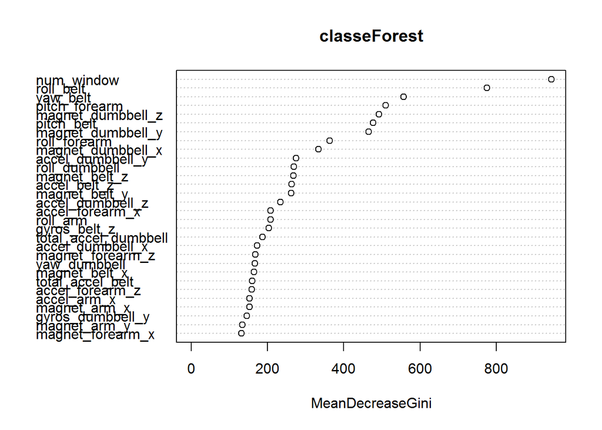

```r
# varImp(classeForest)
varImpPlot(classeForest)
```

Both methods agree on the nine most significant predictors. In order to guard against overfitting, we train the random forest model again on the training subset of the full training data, using only these predictors, and again measure its accuracy on the testing subset for cross-validation purposes:

```r
library(randomForest)
set.seed(1)
classeForest = randomForest(classe ~ num_window+yaw_belt+pitch_belt+roll_belt+magnet_dumbbell_x+magnet_dumbbell_y+magnet_dumbbell_z+pitch_forearm+roll_forearm, data=trainingcv )

PredictForest = predict(classeForest, newdata = testingcv)
ctClasserf<-table(testingcv$classe, PredictForest)
ctClasserf
```

```
##    PredictForest
##        A    B    C    D    E
##   A 1674    0    0    0    0
##   B    1 1138    0    0    0
##   C    0    1 1025    0    0
##   D    0    0    3  960    1
##   E    0    0    0    0 1082
```

```r
# accuracy on test set
accuracy<-sum(diag(ctClasserf))/sum(ctClasserf)
accuracy
```

```
## [1] 0.9989805
```

This also achieves almost perfect accuracy, and we now have more confidence that it will perform just as well on other out-of-sample data sets, with error rates comparable to what we have observed on our “testing” sub-set of the training data, this being

```r
# out-of-sample error rate prediction
1-accuracy
```

```
## [1] 0.001019541
```

### We repeat the two tests for relative importance of the predictors, but now on the restricted set:

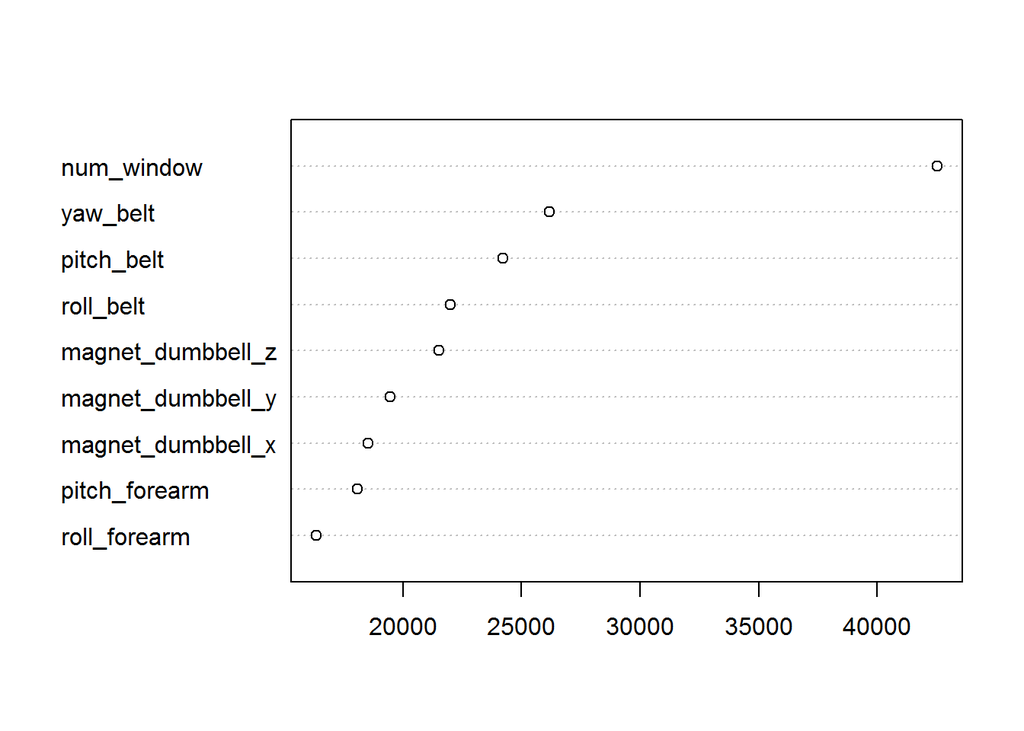

```r
vu = varUsed(classeForest, count=TRUE)
vusorted = sort(vu, decreasing = FALSE, index.return = TRUE)
dotchart(vusorted$x, names(classeForest$forest$xlevels[vusorted$ix]))
```

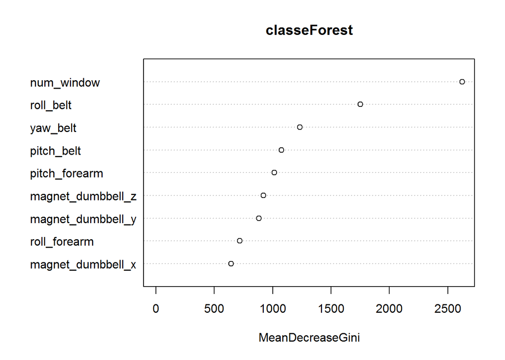

```r
vImp<-varImp(classeForest,count=TRUE)
varImpPlot(classeForest)
```

## Now we make predictions on the out of sample test data

```r
PredictTest = predict(classeForest, newdata = testdf)
PredictTest
```

```
##  1  2  3  4  5  6  7  8  9 10 11 12 13 14 15 16 17 18 19 20
##  B  A  B  A  A  E  D  B  A  A  B  C  B  A  E  E  A  B  B  B
## Levels: A B C D E
```

## Write predictions as 20 single character text files, for submission.

```r
answers<-as.character(PredictTest)
pml_write_files = function(x){
  n = length(x)
  for(i in 1:n){
    filename = paste0("problem_id_",i,".txt")
    write.table(x[i],file=filename,quote=FALSE,row.names=FALSE,col.names=FALSE)
  }
}
pml_write_files(answers)
```

All 20 predictions are correct. Given this, it seems unnecessary to carry out more involved cross-validation procedures (eg n-fold, rfcv) than were used here.